# Course Intro & Probability

Matthew Talluto

02.05.2022

# Course Introduction

- Introduce ourselves - name, research area, what you want from this course
- The [course web page](https://mtalluto.github.io/vu_advanced_statistics/) has links to all code and presentations

# Course Introduction

### This course will give you:

- A deeper understanding of how inferential statistics works
- An appreciation of the similarities between Bayesian and frequentist methods
- The ability to think critically about model design

# Course Introduction

### This course will give you:

- A deeper understanding of how inferential statistics works
- An appreciation of the similarities between Bayesian and frequentist methods
- The ability to think critically about model design

### And not so much:

- A giant toolbox of ready-made models, with variations for every potential problem

# Course Introduction

### This course will give you:

- A deeper understanding of how inferential statistics works
- An appreciation of the similarities between Bayesian and frequentist methods
- The ability to think critically about model design

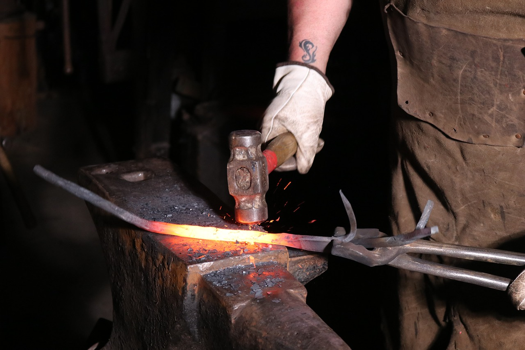

### And not so much:

- A giant toolbox of ready-made models, with variations for every potential problem

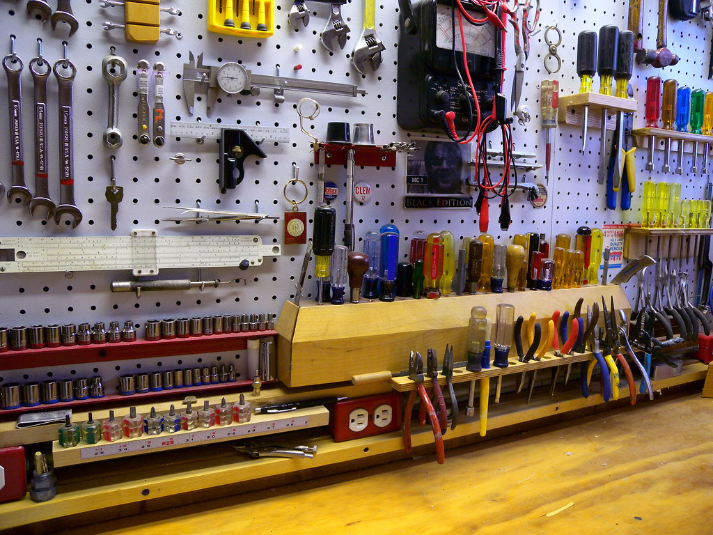

# Why Bayes?

Why statistics at all? What is the goal of statistical analysis?

- I want to describe some phenomenon (“model”)
- I have some general (“prior”) knowledge about the question
- I gather additional information (“data”)

# Why Bayes?

Why statistics at all? What is the goal of statistical analysis?

- I want to describe some phenomenon (“model”)
- I have some general (“prior”) knowledge about the question
- I gather additional information (“data”)

What is the probability that my model is correct given what I already know about it and what I’ve learned?

# Probabilistic partitions

Imagine a box with a total area of 1, representing all possible events

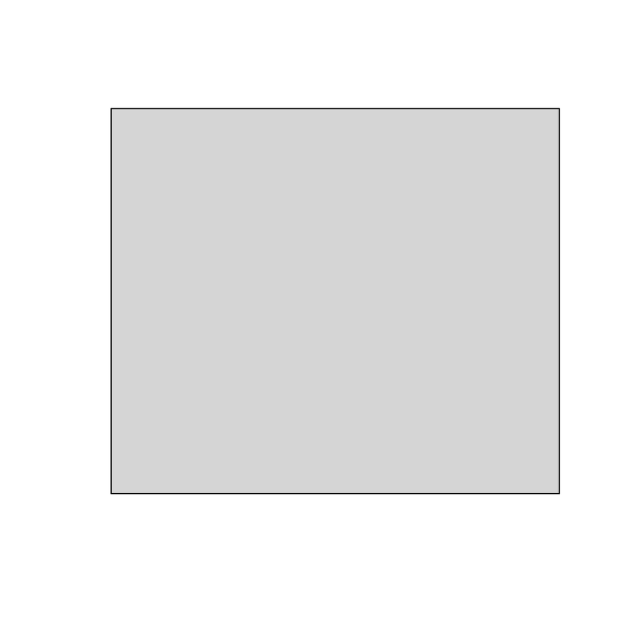

# Probabilistic partitions

- An event A has some probability of occurring: *pr(A)* (**marginal probability**)

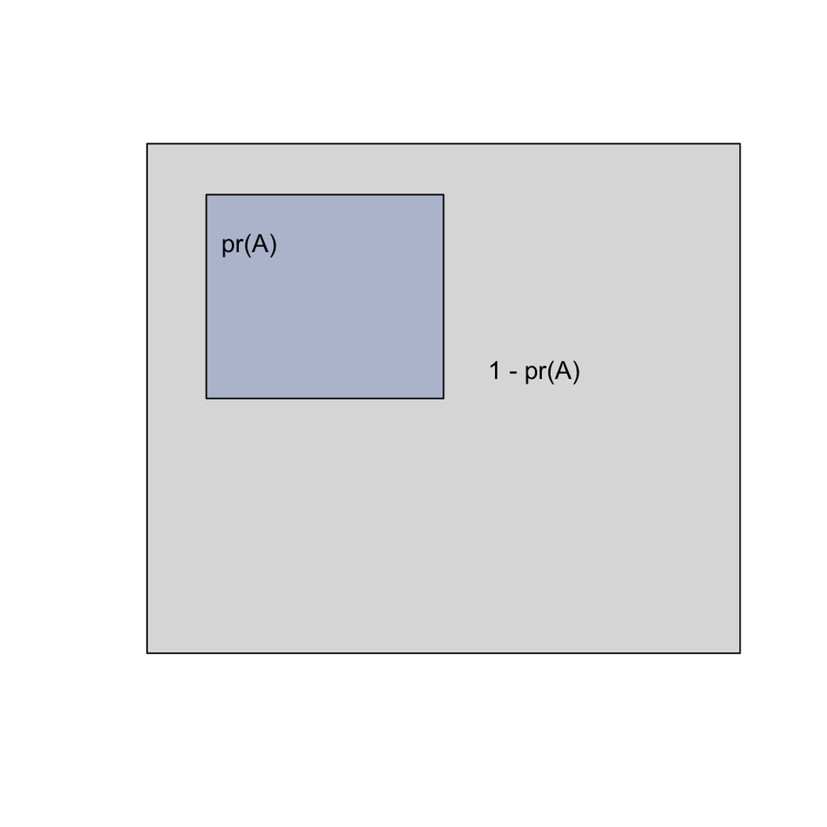

# Probabilistic partitions

- An event A has some probability of occurring: *pr(A)* (**marginal probability**)
- A second event, B, has multiple possible relationships to A.
  - If A and B never occur together, the events are **disjoint**

|  | !B | B |
| --- | --- | --- |
| !A | 1 - pr(A) - pr(B) | pr(B) |
| A | pr(A) | 0 |

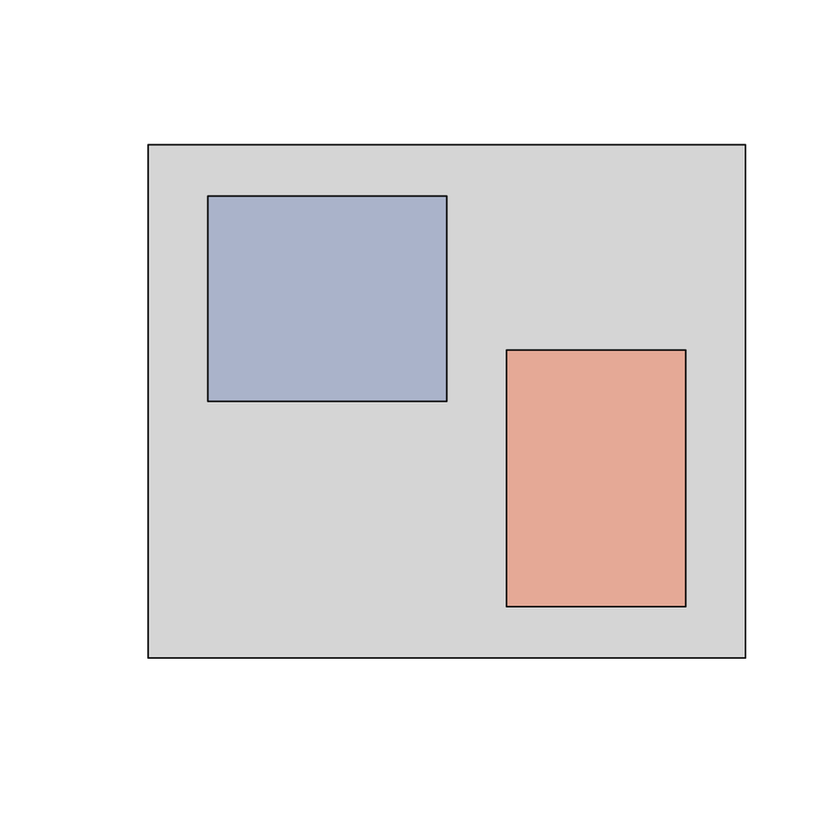

# Probabilistic partitions

- An event A has some probability of occurring: *pr(A)*
- A second event, B, has multiple possible relationships to A:
  - If A and B never occur together, the events are **disjoint**
  - If the two overlap, we can say that they **intersect**

|  | !B | B |
| --- | --- | --- |
| !A | 1 - pr(A) - pr(B) + pr(A,B) | pr(B) - pr(A,B) |
| A | pr(A) - pr(A,B) | pr(A,B) |

# Probabilistic partitions

- An event A has some probability of occurring: *pr(A)*
- A second event, B, has multiple possible relationships to A:
  - If A and B never occur together, the events are **disjoint**
  - If the two overlap, we can say that they **intersect**
- pr(A,B) = the probability of both (**joint probability**)
  - Also written $A \cap B$ (the intersection of A and B)

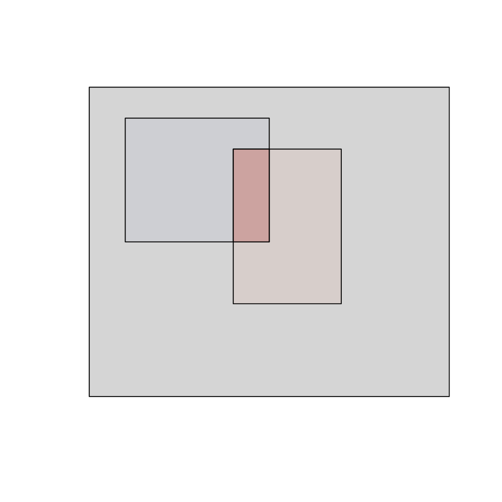

# Probabilistic partitions

- An event A has some probability of occurring: *pr(A)*
- A second event, B, has multiple possible relationships to A:
  - If A and B never occur together, the events are **disjoint**
  - If the two overlap, we can say that they **intersect**
- pr(A,B) = the probability of both (**joint probability**)
  - Also written $A \cap B$ (the intersection of A and B)
- pr(A) + pr(B) - pr(A,B) is the *union* ($A \cup B$)
  - the chance of *at least one event*
  - for **disjoint** events, pr(A,B) = 0, so $A \cup B = pr(A) + pr(B)$

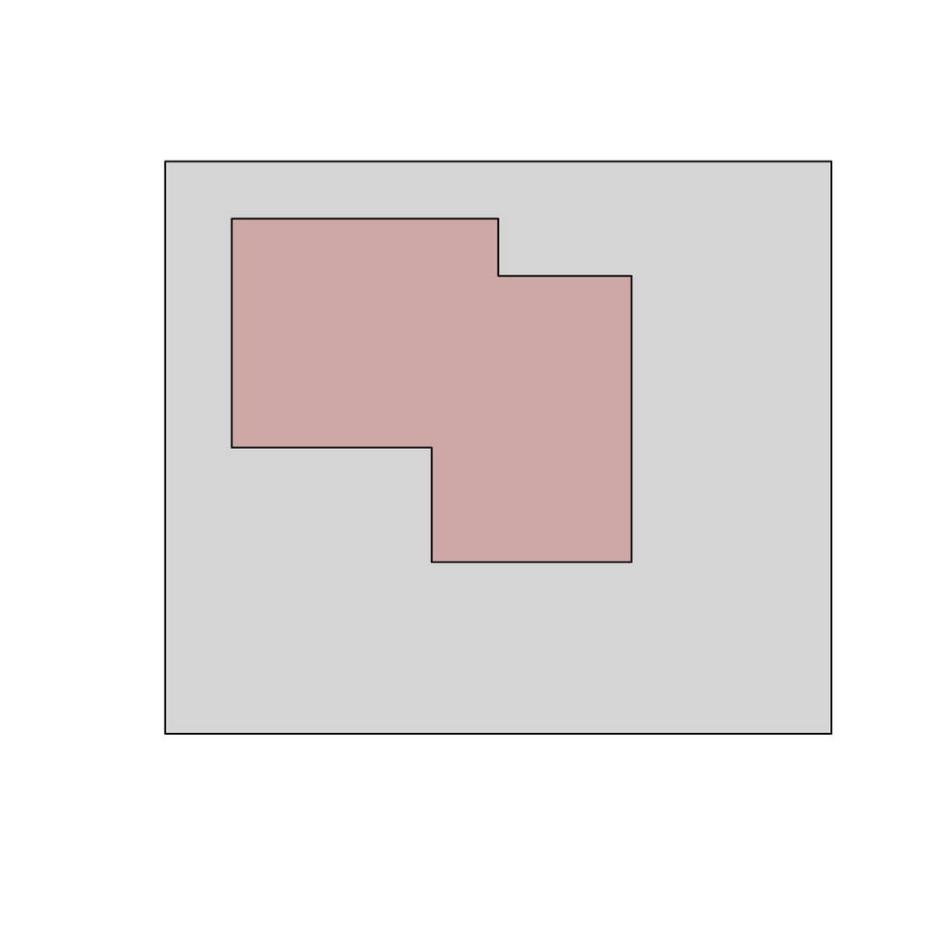

# Independence

- A and B are independent if pr(A) is not influenced by whether B has occurred, and vice-versa
- $pr(A,B) = pr(A)pr(B)$ (**joint probability**)
- $pr(A|B) = pr(A)$
- $pr(B|A) = pr(B)$

# Conditional probability

- $pr(A|B)$ is the probability that $A$ occurs, given that we already know $B$ has occurred
- We notate the opposite (pr that $A$ occurs given that $B$ has not): $pr(A|'B)$
- We can define conditional probabilities in terms of **joint** and **marginal** probabilities

$$pr(A,B) = pr(A|B)pr(B)$$

# Conditional probability

- $pr(A|B)$ is the probability that $A$ occurs, given that we already know $B$ has occurred
- We notate the opposite (pr that $A$ occurs given that $B$ has not): $pr(A|'B)$
- We can define conditional probabilities in terms of **joint** and **marginal** probabilities

$$pr(A,B) = pr(A|B)pr(B)$$

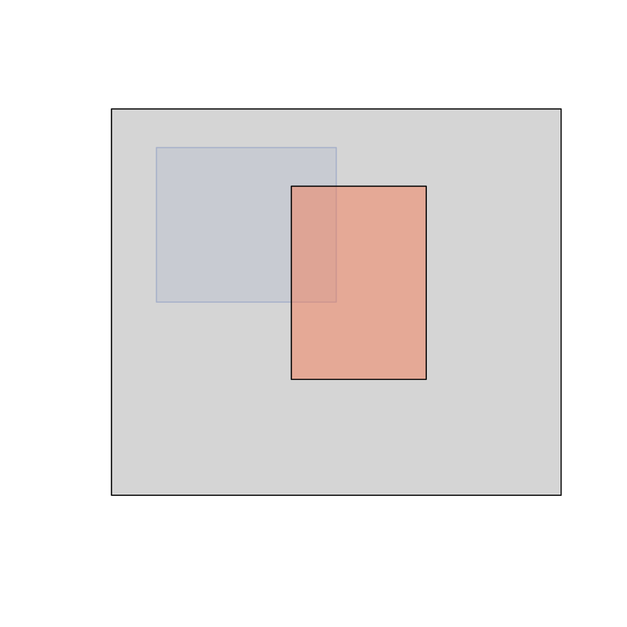

# Conditional probability

- $pr(A|B)$ is the probability that $A$ occurs, given that we already know $B$ has occurred
- We notate the opposite (pr that $A$ occurs given that $B$ has not): $pr(A|'B)$
- We can define conditional probabilities in terms of **joint** and **marginal** probabilities

$$pr(A,B) = pr(A|B)pr(B)$$

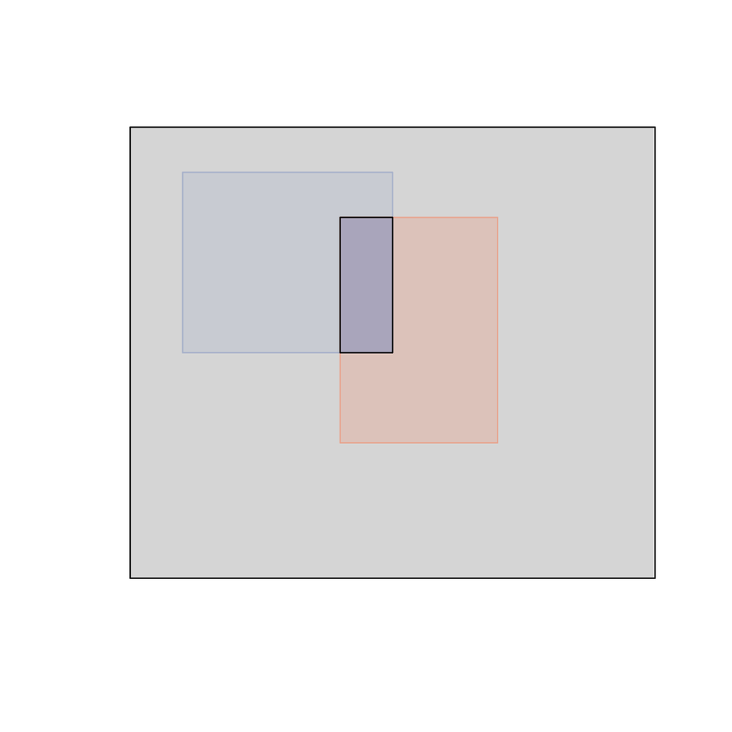

# So now that we have learned how to manupulate probabilities….

Can anyone *define* probability?

# Manipulating conditional probabilities

**Are you a (latent) zombie?**

**The problem**:  
0.1% of the population is infected with a parasite that will turn them into zombies. We have a test, but it is imperfect, with a *false negative rate* = 0.5% and a *false positive rate* = 1%.

You take the test, and the result is positive. What is the probability that you are actually going to become a zombie?

[figure not shown]

# Manipulating conditional probabilities

**Are you a (latent) zombie?**

**The problem**:  
0.1% of the population is infected with a parasite that will turn them into zombies. We have a test, but it is imperfect, with a *false negative rate* = 0.5% and a *false positive rate* = 1%.

You take the test, and the result is positive. What is the probability that you are actually going to become a zombie?

**Hints**

- Define the partitions:
  - Zombie ($Z$) or not a zombie ($'Z = 1 - Z$)
  - Positive test ($T$) or negative test ($'T = 1 - T$)
- Assign known numbers to statements of **joint**, **marginal**, or **conditional** probabilities
- Compute unknowns using the conditional probability rule: $pr(A,B) = pr(A|B)pr(B)$
- Assign concrete numbers: imagine testing 1,000,000 people. How many are zombies? How many test positive? How many test positive and are zombies?

[figure not shown]

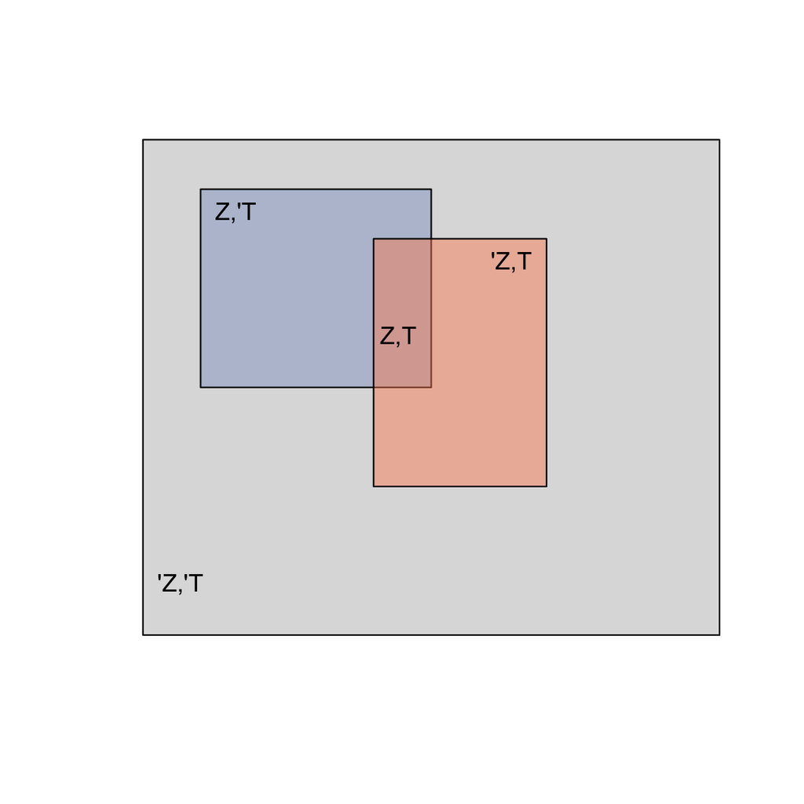